# Uncertainty estimation for KLD

Niklas Hartung

2023-08-31

Loading required packages:

```r
library(kldest)
library(ggplot2)
set.seed(0)
```

We investigate the following pairs of distributions, for which analytical KL divergence values are known:

- $\mathcal{N}(0,1)$ vs. $\mathcal{N}(1,2^2)$,
- $\mathcal{U}(1,2)$ vs. $\mathcal{U}(0,4)$,
- $\text{Exp}(1)$ vs. $\text{Exp}(12)$.

```r
p <- list(
    gaussian    = list(mu1 = 0, sigma1 = 1, mu2 = 1, sigma2 = 2^2),
    uniform     = list(a1 = 1, b1 = 2, a2 = 0, b2 = 4),
    exponential = list(lambda1 = 1, lambda2 = 1/12)
)
distributions <- list(
    gaussian = list(
        samples = function(n, m) {
            X <- rnorm(n, mean = p$gaussian$mu1, sd = sqrt(p$gaussian$sigma1))
            Y <- rnorm(m, mean = p$gaussian$mu2, sd = sqrt(p$gaussian$sigma2))
            list(X = X, Y = Y)
        },
        kld = do.call(kld_gaussian, p$gaussian)
    ),
    uniform = list(
        samples = function(n, m) {
            X <- runif(n, min = p$uniform$a1, max = p$uniform$b1)
            Y <- runif(m, min = p$uniform$a2, max = p$uniform$b2)
            list(X = X, Y = Y)
        },
        kld = do.call(kld_uniform, p$uniform)
    ),
    exponential = list(
        samples = function(n, m) {
            X <- rexp(n, rate = p$exponential$lambda1)
            Y <- rexp(m, rate = p$exponential$lambda2)
            list(X = X, Y = Y)
        },
        kld = do.call(kld_exponential, p$exponential)
    )
)
```

Analytical values for Kullback-Leibler divergences in test cases:

```r
vapply(distributions, function(x) x$kld, 1)
```

```
##    gaussian     uniform exponential
##   0.4431472   1.3862944   1.5682400
```

### Simulation scenarios

For each of the distributions specified above, samples of different sizes are drawn, with several replicates per distribution and sample size.

```r
samplesize <- c(10,100,1000,10000)
nRep       <- 100L

scenarios <- combinations(
    distribution = names(distributions),
    sample.size  = samplesize,
    replicate    = 1:nRep
)
```

### Algorithms & bootstrap methods

The following algorithms are considered:

```r
algorithms <- list(
    nn1  = kld_est_1nn,
    kde1 = kld_est_kde1
)
nAlgo   <- length(algorithms)
```

Choose the bootstrap method to be considered:

```r
resampling_method <- "subsampling"
#resampling_method <- "bootstrap"
resampling_fun <- switch(resampling_method,
       bootstrap   = kld_ci_bootstrap,
       subsampling = function(...) kld_ci_subsampling(..., size = sqrt)
)
```

## Uncertainty quantification of estimators

```r
# allocating results matrices
nscenario  <- nrow(scenarios)
covered <- matrix(nrow = nscenario,
                  ncol = nAlgo,
                  dimnames = list(NULL, names(algorithms)))

for (i in 1:nscenario) {

    dist <- scenarios$distribution[i]
    n    <- scenarios$sample.size[i]

    samples <- distributions[[dist]]$sample(n = n, m = n)
    kld     <- distributions[[dist]]$kld

    X <- samples$X
    Y <- samples$Y

    # different algorithms are evaluated on the same samples
    for (j in 1:nAlgo) {
        kldboot <- resampling_fun(X, Y, estimator = algorithms[[j]], B = 500L)
        covered[i,j] <- kldboot$ci[1] <= kld && kld <= kldboot$ci[2]
    }
}
```

Combine scenarios with CI coverage information:

```r
results <- cbind(scenarios, covered) |> reshape2::melt(measure.vars = names(algorithms),
                                                    value.name = "covered",
                                                    variable.name = "algorithm")
```

Compute coverage per sample size / algorithm / distribution:

```r
coverage <- reshape2::dcast(results, sample.size + algorithm + distribution ~ .,
                value.var = "covered", fun.aggregate = function(x) mean(x, na.rm = TRUE))
names(coverage)[4] <- "coverage"
```

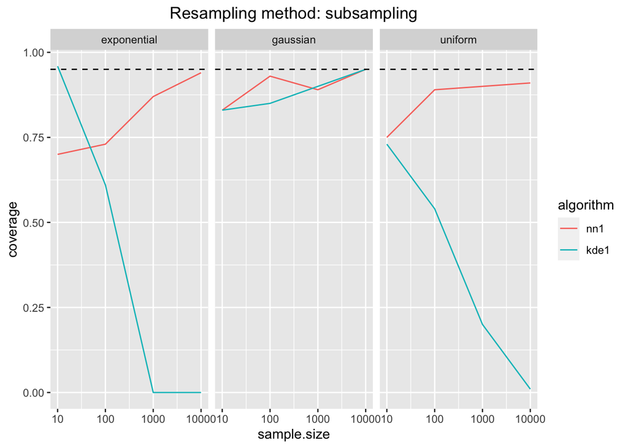

```r
ggplot(coverage, aes(x=sample.size, y = coverage, color = algorithm)) +
    facet_wrap("distribution") +
    geom_line() +
    scale_x_log10() +
    geom_hline(yintercept = 0.95, lty = 2) +
    ggtitle(paste("Resampling method:",resampling_method)) +
    theme(plot.title = element_text(hjust = 0.5))
```

$\Rightarrow$ the subsampling bootstrap works well for the 1-NN estimator! For all three scenarios, the asymptotic nominal level is approximately held for the largest sample size. In contrast, for KDE it doesn’t work well. This is most likely caused by the biased estimates of this method for the non-Gaussian cases.

## For comparison: the current approach

Currently, we resample from $\hat Q$, but leave the sample $X$ as is. For proof of concept, I use the Gaussian scenario and estimate $\hat Q$ to be a Gaussian, too.

```r
n <- 1000
covered_approx <- numeric(nRep)
for (i in 1:nRep) {
    Xi <- rnorm(n = n)
    kld_approx <- numeric(nRep)
    for (j in 1:nRep) {
        Yij <- rnorm(n = n, mean = 1, sd = 2)
        kld_approx[j] <- algorithms$nn1(Xi, Yij)
    }
    ci <- quantile(kld_approx, c(0.025, 0.975))
    kl_true <- distributions$gaussian$kld
    covered_approx[i] <- ci[1] <= kl_true && kl_true <= ci[2]
}
coverage <- mean(covered_approx)
coverage
```

```
## [1] 0.96
```

$\Rightarrow$ in this easy example, coverage is quite good (indeed, similar to the nominal one!)